# Nonlinear models part 1: Intro to nonlinear models

Nick Green, Kennesaw State University

November 23, 2021

# 1 Overview

Many biological processes and phenomena are related in ways that do not form straight lines. While linear models and the assumption of linearity are powerful ways to think about and analyze biological phenomena, they are not always appropriate. This module will introduce you to some ways of exploring situations where one quantity does not scale as a constant proportion of another.

# 2 Background

So far we have learned about a wide variety of linear models, which predict some response variable *Y* as a linear function of one or more predictor variables *X*. A linear function is one that takes the form $Y=mX+b$, where *m* and *b* are constants. The scalar *m* defines how much *Y* changes for every unit increase in *X* (i.e., if *X* increases by 1, then *Y* increases by *m*). In order for the relationship to be a straight line, the change in *Y* resulting from a change in *X* does not vary. In other words, the slope of the line ($dY/dX$) is a constant. This is what “linear” means.

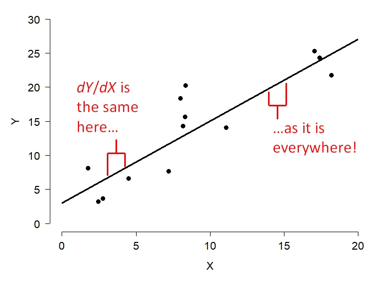

Some relationships do not follow such a rule. Consider the relationship below. Is the slope constant?

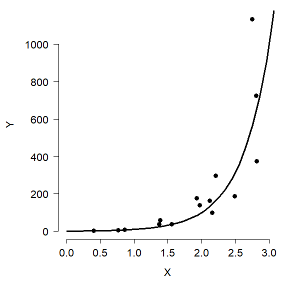

As shown, the relationship between *Y* and *X* is nonlinear because the slope of the line is different at different *X*. However, we can linearize the relationship by taking the logarithm of *Y*. Compare the left panel below to the right panel. All that has changed is the *y*-axis scaling.

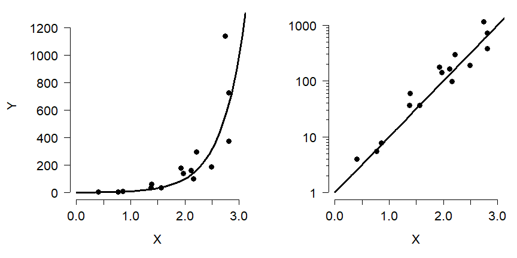

Other relationships are not amenable to this kind of transformation. For example, the figure below shows *Y* varying as a **Gompertz function** of *X*. Unlike the log-linear model shown above, there is no transform that will linearize the Gompertz curve. So, if we wanted to analyze data that followed such a pattern, we would need a different set of tools.

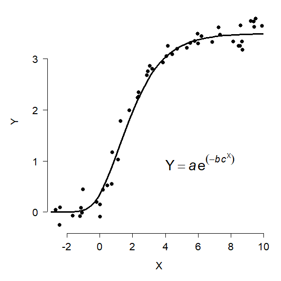

# 3 Nonlinear least squares (NLS)

The basic **nonlinear least squares (NLS)** model has some parts in common with the basic linear regression model (LM). In the state-space GLM notation, we can see that the relationship between the observed *Y* variables and the expected value $\mu$ is the same as in the LM. However, the relationship between the expected value and the predictor variables is not the same.

| Component | Linear model (LM) | Nonlinear model (NLS) |
| --- | --- | --- |
| Stochastic part | $Y~Normal\left(\mu,\ \sigma^2\right)$ | $Y~Normal\left(\mu,\ \sigma^2\right)$ |
| Link function | $\mu=\eta$ | $\mu=\eta$ |
| Expected value | $\eta=\beta_0+\beta_{1}X$ | $\mu=f(X,\theta)$ |

In the NLS model, as with LM, the response variable *Y* is drawn from a normal distribution with mean $\mu$ and variance $\sigma^2$. Also like LM, the mean $\mu$ is identical to the predictor $\eta$. Unlike LM, in NLS the expected value $\eta$ is not a linear function but instead a function *f* of the explanatory variable *X* and some vector of parameters $\theta$. The function $f\left(X,\ \theta\right)$ can be any number of functions. If $f\left(X,\ \theta\right)$ is a linear function, then the NLS model becomes a linear model.

The equations above show an important assumption of NLS: the errors are normally distributed with constant variance. In some cases, the function $f\left(X,\ \theta\right)$ can be transformed to make it linear. However, doing so will likely make the errors non-normal or heteroscedastic, which means that the LM on transformed data wouldn’t be appropriate anyway.

There are several methods of fitting NLS models. Unlike LM, where it is relatively straightforward to solve some linear algebra problems and get stable parameter estimates, in NLS the parameters must be approximated by searching the parameter space (i.e., set of possible values) for $\theta$ that minimize the sum of squared residuals. The methods for computing these estimates are extremely complicated and sensitive to starting inputs, and we won’t go into them here. Bolker (2008) gives an overview of some of these methods.

[**Go back to main page**](https://greenquanteco.github.io/index.html)

# 4 References

Bolker, B. M. 2008. Ecological models and data in R. Princeton University Press, Princeton, New Jersey, USA.

# 5 Legal notice

This site is for educational purposes only. This work and its content is released under the [Creative Commons Attribution-ShareAlike 4.0](https://creativecommons.org/licenses/by-sa/4.0/) license. Inclusion of third-party data falls under guidelines of fair use as defined in [section 107 of the US Copyright Act of 1976](https://www.law.cornell.edu/uscode/text/17/107).